# Data Science Demo - Hortonworks Modeling airline delays with Hadoop and Python

In this demo we will explore the airline delay dataset available here: http://stat-computing.org/dataexpo/2009/the-data.html This dataset includes details about flights in the US from the years 1987-2008.

Our goal is to build a supervised learning model to predict flight delays for flights leaving Ohare International airport (ORD). We will use the year 2007 data to build the model, and test it's validity on the year 2008.

```python
# Python library imports: numpy, random, sklearn, pandas, etc

import warnings
warnings.filterwarnings('ignore')

import random
import numpy as np

from sklearn import linear_model, cross_validation, metrics, svm
from sklearn.metrics import classification_report, confusion_matrix, precision_recall_fscore_support
from sklearn.ensemble import RandomForestClassifier
from sklearn.preprocessing import StandardScaler

import pandas as pd
import matplotlib.pyplot as plt

%matplotlib inline
```

```python
%%javascript
IPython.OutputArea.auto_scroll_threshold = 30;
```

```python
# function to read HDFS file into dataframe using PyDoop

import pydoop.hdfs as hdfs
def read_csv_from_hdfs(path, cols, col_types=None):
  files = hdfs.ls(path);
  pieces = []
  for f in files:
    pieces.append(pd.read_csv(hdfs.open(f), names=cols, dtype=col_types))
  return pd.concat(pieces, ignore_index=True)
```

## Data Exploration

First we explore the dataset to determine which variables are reasonable to use for this prediction task. We will take a look at the year 2007 as an example

```python
# read 2007 year file
cols = ['year', 'month', 'day', 'dow', 'DepTime', 'CRSDepTime', 'ArrTime', 'CRSArrTime', 'Carrier', 'FlightNum',
        'TailNum', 'ActualElapsedTime', 'CRSElapsedTime', 'AirTime', 'ArrDelay', 'DepDelay', 'Origin', 'Dest',
        'Distance', 'TaxiIn', 'TaxiOut', 'Cancelled', 'CancellationCode', 'Diverted', 'CarrierDelay',
        'WeatherDelay', 'NASDelay', 'SecurityDelay', 'LateAircraftDelay'];
flt_2007 = read_csv_from_hdfs('airline/delay/2007.csv', cols)

flt_2007.shape
```

```
(7453216, 29)
```

So we have 7.4M+ flights in 2007 and 29 variables.

Our "target" variable will be DepDelay (departure delay in minutes). To build a classifier, we further refine our target variable into a binary variable by defining a "delay" as having 15 mins or more of delay, and "non-delay" otherwise.

Let's look at possible predictive variables: - month: winter months should have more delays than summer months - day of month: this is likely not a very predictive variable - day of week: weekend vs. weekday - Carrier: we might expect some carriers to be more prone to delays than others - Dest: we expect some airports to be more prone to delays than others - Distance: interesting to see if this variable is a good predictor of delay

Note that we won't use many other variables such as TaxiIn, TaxiOut or SecurityDelay since they cannot be used ahead of time for prediction.

```
      DepDelay
Dest
LGA       3781
EWR       3044
MSP       2756
DFW       2565
LAX       2473
PHL       2189
BOS       2089
DTW       1971
CLT       1907
DEN       1869
```

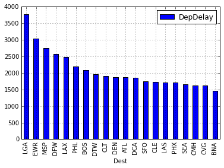

```python
df = flt_2007[flt_2007['Origin']=='ORD'].dropna(subset=['DepDelay'])
df['DepDelay'] = df[['DepDelay']].apply(lambda x: x>=15)

grouped = df[['DepDelay', 'Dest']].groupby('Dest').sum()
dest = grouped.sort(['DepDelay'], ascending=False)
print dest[:10]

dest[:20].plot(kind='bar')
```

Similarly, some carriers are notorious for delays. Let's see who those are...

```
         DepDelay
Carrier
UA          28388
MQ          26305
AA          23410
OO          12810
YV           9325
```

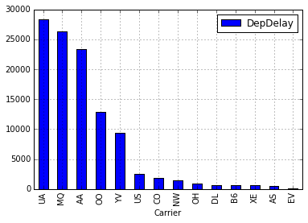

```python
grouped = df[['DepDelay', 'Carrier']].groupby('Carrier').sum()
dest = grouped.sort(['DepDelay'], ascending=False)
print dest[:5]

dest[:15].plot(kind='bar')
```

Okay, so now let's look at the "month" variable. Do we see a correlation between winter months and higher occurent of delays?

```
       DepDelay
month
1         10100
2         11316
3         10389
4          8875
5          7010
6          9491
7          8711
8         10348
9          6195
10         7093
11         7060
12        12758
```

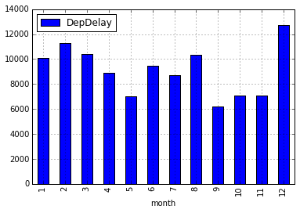

```python
grouped = df[['DepDelay', 'month']].groupby('month').sum()
print grouped
grouped.plot(kind='bar')
```

## Pre-processing

Now let's turn to building a feature matrix for our predictive model.

And a PIG script - preprocess1.pig

```python
%%script pig --bg --err pig_out

Register 'util.py' USING jython as util;
DEFINE preprocess(year_str, airport_code) returns data
{
        -- load airline data from specified year (need to specify fields since it's not in HCat)
        airline = load 'airline/delay/$year_str.csv' using PigStorage(',')
            as (Year: int, Month: int, DayOfMonth: int, DayOfWeek: int, DepTime: chararray,
                CRSDepTime, ArrTime, CRSArrTime, Carrier: chararray, FlightNum, TailNum, ActualElapsedTime,
                CRSElapsedTime, AirTime, ArrDelay, DepDelay: int, Origin: chararray, Dest: chararray, Distance: int,
                TaxiIn, TaxiOut, Cancelled: int, CancellationCode, Diverted, CarrierDelay, WeatherDelay,
                NASDelay, SecurityDelay, LateAircraftDelay);

        -- keep only instances where flight was not cancelled
        airline_flt = filter airline by Cancelled == 0;

        -- Keep only fields I need
        airline2 = foreach airline_flt generate Year as year, Month as month, DayOfMonth as day, DayOfWeek as dow,
                        Carrier as carrier, Origin as origin, Dest as dest, Distance as distance,
                        DepTime as time, DepDelay as delay;

        airline3 = filter airline2 by origin == '$airport_code';
        $data = foreach airline3 generate delay, month, day, dow, util.get_hour(time) as hour, distance,
                    util.is_bad_carrier(carrier) as is_bad_carrier, util.is_bad_dest(dest) as is_bad_dest,
                    util.days_from_nearest_holiday(year, month, day) as hdays;
};

ORD_2007 = preprocess('2007', 'ORD');
rmf airline/fm/ord_2007_1;
store ORD_2007 into 'airline/fm/ord_2007_1' using PigStorage(',');

ORD_2008 = preprocess('2008', 'ORD');
rmf airline/fm/ord_2008_1;
store ORD_2008 into 'airline/fm/ord_2008_1' using PigStorage(',');
```

```
Starting job # 0 in a separate thread.
```

Let's look at the output as the script continues to process...

```python
while True:
    line = pig_out.readline()
    if not line:
        break
    sys.stdout.write("%s" % line)
    sys.stdout.flush()
```

[output not shown]

[output cut: 143 more lines]

Let's look at the results with Hue - two files are generates: airline/fm/ord_2007_1 and airline/fm/ord_2008_1 (the "1" indicates this is the first iteration; more on that below)

PIG is great for pre-procesing raw data into a feature matrix, but it's not the only choice. We can use other tools such as HIVE, Cascading, Scalding or Spark for this type of pre-processing.

## Modeling

Now we have the files ord_2007_1 and ord_2008_1 under 'airline/fm' folder in HDFS. Let's read those files into Python, and prepare the training/testing datasets as Pandas DataFrame objects.

```python
# read files
cols = ['delay', 'month', 'day', 'dow', 'hour', 'distance', 'bad_carrier', 'bad_dest', 'days_from_holiday']
col_types = {'delay': int, 'month': int, 'day': int, 'dow': int, 'hour': int, 'distance': int,
             'bad_carrier': int, 'bad_dest': int, 'days_from_holiday': int}

data_2007 = read_csv_from_hdfs('airline/fm/ord_2007_1', cols, col_types)
data_2008 = read_csv_from_hdfs('airline/fm/ord_2008_1', cols, col_types)

# Create training set and test set
cols.remove('delay')
train_y = data_2007['delay'] >= 15
train_x = data_2007[cols]
test_y = data_2008['delay'] >= 15
test_x = data_2008[cols]

# Create scaled/normalized version of feature matrix, to be used in SGD models
scaler = StandardScaler()
scaler.fit(train_x)
train_x_sc = scaler.transform(train_x.copy())
test_x_sc = scaler.transform(test_x.copy())

print train_x.head(5)
```

```
   month  day  dow  hour  distance  bad_carrier  bad_dest  days_from_holiday
0      1   25    4    10       719            0         1                 10
1      1   28    7    15       925            0         0                 13
2      1   29    1    20       316            0         0                 14
3      1   17    3    18       719            0         1                  2
4      1   12    5    20       316            0         0                  3
```

Now we build a logistic regression model and evaluate its performance on the testing dataset from 2008

```python
%%time
# Create logistic regression model with L2 regularization
clf_lr = linear_model.LogisticRegression(penalty='l2', class_weight='auto')
clf_lr.fit(train_x, train_y)

# Predict output labels on test set
pr = clf_lr.predict(test_x)

# display evaluation metrics
cm = confusion_matrix(test_y, pr)
print("Confusion matrix")
print(cm)
report_lr = precision_recall_fscore_support(list(test_y), list(pr), average='micro')
print "precision = %0.2f, recall = %0.2f, F1 = %0.2f\n" % \
        (report_lr[0], report_lr[1], report_lr[2])

print train_x.shape
```

```
Confusion matrix
[[149618  90276]
 [ 34570  60866]]
precision = 0.40, recall = 0.64, F1 = 0.49

(359169, 8)
CPU times: user 9.97 s, sys: 122 ms, total: 10.1 s
Wall time: 10.1 s
```

Nice; we got some initial precision/recall numbers. Let's compare this to two other algorithms: - Logistic Regression with SGD (Stochastic Gradient Descent) - Random Forest

```python
%%time
# Create SGD Logistic regression classifier with 100 iterations
# SGD is very sensitive to feature range, so using scaled (normalized) version of feature matrix
clf_sgd = linear_model.SGDClassifier(loss='log', penalty='l2', n_iter=200, n_jobs=-1, class_weight='auto')
clf_sgd.fit(train_x_sc, train_y)

# Predict output labels on test set
pr = clf_sgd.predict(test_x_sc)

# display evaluation metrics
cm = confusion_matrix(test_y, pr)
print("Confusion matrix")
print(cm)
report_sgd = precision_recall_fscore_support(list(test_y), list(pr), average='micro')
print "precision = %0.2f, recall = %0.2f, F1 = %0.2f\n" % \
        (report_sgd[0], report_sgd[1], report_sgd[2])
```

```
Confusion matrix
[[143052  96842]
 [ 39292  56144]]
precision = 0.37, recall = 0.59, F1 = 0.45

CPU times: user 8.36 s, sys: 13 ms, total: 8.37 s
Wall time: 8.46 s
```

```python
%%time
# Create Random Forest classifier with 50 trees
clf_rf = RandomForestClassifier(n_estimators=50, n_jobs=-1)
clf_rf.fit(train_x, train_y)

# Evaluate on test set
pr = clf_rf.predict(test_x)

# print results
cm = confusion_matrix(test_y, pr)
print("Confusion matrix")
print(cm)
report_svm = precision_recall_fscore_support(list(test_y), list(pr), average='micro')
print "precision = %0.2f, recall = %0.2f, F1 = %0.2f\n" % \
        (report_svm[0], report_svm[1], report_svm[2])
# Print feature importance, as detetmined by RF
imp = pd.DataFrame({'name': train_x.columns, 'score': clf_rf.feature_importances_}).sort('score')
print imp
```

```
Confusion matrix
[[204378  35516]
 [ 58557  36879]]
precision = 0.51, recall = 0.39, F1 = 0.44

                name     score
6           bad_dest  0.008452
5        bad_carrier  0.019521
2                dow  0.043230
0              month  0.064370
7  days_from_holiday  0.075154
1                day  0.086537
3               hour  0.248196
4           distance  0.454540
CPU times: user 36.7 s, sys: 918 ms, total: 37.7 s
Wall time: 12.7 s
```

Note that the output of a Random Forest model also includes the relative importance of features. We see that in this model, distance is by-far the most important feature in the model, followed by hour of the day.

## Modeling Iteration 2

How can improve this model?

One way that is to bring in more data - enrich our dataset. One idea in that direction is to layer-in weather data. We can get this data from a publicly available dataset here: http://www.ncdc.noaa.gov/cdo-web/datasets/

Our 2nd PIG script preprocess2.pig, in a manner similar to preprocess1.pig, does all the data munging and preparation, merging these two datasets into a combined feature matrix at "airline/fm/ord_2007_2" and "airline/fm/ord_2008_2" in HDFS.

```python
%%script pig --bg --err pig_out2

register 'util.py' USING jython as util;

-- Helper macro to load data and join into a feature vector per instance
DEFINE preprocess(year_str, airport_code) returns data
{
    load airline data from specified year (need to specify fields since it's not in HCat)
    airline = load 'airline/delay/$year_str.csv' using PigStorage(',')
                    as (Year: int, Month: int, DayOfMonth: int, DayOfWeek: int, DepTime: chararray, CRSDepTime, ArrTime,
                        CRSArrTime, Carrier: chararray, FlightNum, TailNum, ActualElapsedTime, CRSElapsedTime, AirTime,
                        ArrDelay, DepDelay: int, Origin: chararray, Dest: chararray, Distance: int, TaxiIn, TaxiOut,
                        Cancelled: int, CancellationCode, Diverted, CarrierDelay, WeatherDelay, NASDelay,
                        SecurityDelay, LateAircraftDelay);

    -- keep only instances where flight was not cancelled
    airline_flt = filter airline by Cancelled == 0;

    -- Keep only fields I need
    airline2 = foreach airline_flt generate Year as year, Month as month, DayOfMonth as day, DayOfWeek as dow,
                        Carrier as carrier, Origin as origin, Dest as dest, Distance as distance,
                        DepTime as time, DepDelay as delay, util.to_date(Year, Month, DayOfMonth) as date;

    -- load weather data
    weather = load 'airline/weather/$year_str.csv' using PigStorage(',')
                    as (station: chararray, date: chararray, metric, value, t1, t2, t3, time);

    -- keep only TMIN and TMAX weather observations from ORD
    weather_tmin = filter weather by station == 'USW00094846' and metric == 'TMIN';
    weather_tmax = filter weather by station == 'USW00094846' and metric == 'TMAX';
    weather_prcp = filter weather by station == 'USW00094846' and metric == 'PRCP';
    weather_snow = filter weather by station == 'USW00094846' and metric == 'SNOW';
    weather_awnd = filter weather by station == 'USW00094846' and metric == 'AWND';

    joined = join airline2 by date, weather_tmin by date, weather_tmax by date, weather_prcp by date,
                                    weather_snow by date, weather_awnd by date;
    joined2 = filter joined by origin == '$airport_code';
    $data = foreach joined2 generate delay, month, day, dow, util.get_hour(airline2::time) as tod, distance,
                                     util.is_bad_carrier(carrier) as is_bad_carrier, util.is_bad_dest(dest) as is_bad_dest,
                                     util.days_from_nearest_holiday(year, month, day) as hdays,
                                     weather_tmin::value as temp_min, weather_tmax::value as temp_max,
                                     weather_prcp::value as prcp, weather_snow::value as snow, weather_awnd::value as wind;
};

ORD_2007 = preprocess('2007', 'ORD');
rmf airline/fm/ord_2007_2;
store ORD_2007 into 'airline/fm/ord_2007_2' using PigStorage(',');

ORD_2008 = preprocess('2008', 'ORD');
rmf airline/fm/ord_2008_2;
store ORD_2008 into 'airline/fm/ord_2008_2' using PigStorage(',');
```

```
Starting job # 2 in a separate thread.
```

```python
while True:
    line = pig_out2.readline()
    if not line:
        break
    sys.stdout.write("%s" % line)
    sys.stdout.flush()
```

[output not shown]

We now read this data in, convert temparatures to Fahrenheit (note original temp is in Celcius*10), and prepare the training and testing datasets.

```python
# Convert Celcius to Fahrenheit
def fahrenheit(x): return(x*1.8 + 32.0)

# read files
cols = ['delay', 'month', 'day', 'dow', 'hour', 'distance', 'bad_carrier', 'bad_dest', 'days_from_holiday',
        'origin_tmin', 'origin_tmax', 'origin_prcp', 'origin_snow', 'origin_wind']
col_types = {'delay': int, 'month': int, 'day': int, 'dow': int, 'hour': int, 'distance': int,
             'bad_carrier': int, 'bad_dest': int, 'days_from_holiday': int,
             'origin_tmin': float, 'origin_tmax': float, 'origin_prcp': float, 'origin_snow': float, 'origin_wind': float}

data_2007 = read_csv_from_hdfs('airline/fm/ord_2007_2', cols, col_types)
data_2008 = read_csv_from_hdfs('airline/fm/ord_2008_2', cols, col_types)

data_2007['origin_tmin'] = data_2007['origin_tmin'].apply(lambda x: fahrenheit(x/10.0))
data_2007['origin_tmax'] = data_2007['origin_tmax'].apply(lambda x: fahrenheit(x/10.0))
data_2008['origin_tmin'] = data_2008['origin_tmin'].apply(lambda x: fahrenheit(x/10.0))
data_2008['origin_tmax'] = data_2008['origin_tmax'].apply(lambda x: fahrenheit(x/10.0))

cols.remove('delay')
train_y = data_2007['delay'] >= 15
train_x = data_2007[cols]
test_y = data_2008['delay'] >= 15
test_x = data_2008[cols]

#train_x = pd.concat([train_x, pd.get_dummies(train_x['hour'], prefix='hour')], axis=1)
#test_x = pd.concat([test_x, pd.get_dummies(test_x['hour'], prefix='hour')], axis=1)

print train_x.head(5)
data_2007.shape
```

```
   month  day  dow  hour  distance  bad_carrier  bad_dest  days_from_holiday  \
0      1    3    3    10       491            0         0                  2
1      1    3    3    13       590            1         0                  2
2      1    3    3     9       802            1         1                  2
3      1    3    3    13       215            1         0                  2
4      1    3    3     6       528            0         0                  2

   origin_tmin  origin_tmax  origin_prcp  origin_snow  origin_wind
0        33.08        48.02            0            0           70
1        33.08        48.02            0            0           70
2        33.08        48.02            0            0           70
3        33.08        48.02            0            0           70
4        33.08        48.02            0            0           70
```

```
(359169, 14)
```

So let's try Random Forest now with the new features

```python
%%time
# Create Random Forest classifier with 50 trees
clf_rf = RandomForestClassifier(n_estimators=50, max_features=None, n_jobs=-1)
clf_rf.fit(train_x, train_y)

# Evaluate on test set
pr = clf_rf.predict(test_x)

# print results
cm = confusion_matrix(test_y, pr)
print("Confusion matrix")
print(cm)
report_rf = precision_recall_fscore_support(list(test_y), list(pr), average='micro')
print "precision = %0.2f, recall = %0.2f, F1 = %0.2f\n" % \
        (report_rf[0], report_rf[1], report_rf[2])

# Print feature importance, as detetmined by RF
imp = pd.DataFrame({'name': train_x.columns, 'score': clf_rf.feature_importances_}).sort('score')
print imp
```

```
Confusion matrix
[[207792  32102]
 [ 51784  43652]]
precision = 0.58, recall = 0.46, F1 = 0.51

                 name     score
11        origin_snow  0.012661
6            bad_dest  0.014054
0               month  0.021816
2                 dow  0.026589
7   days_from_holiday  0.038122
8         origin_tmin  0.039537
1                 day  0.041822
5         bad_carrier  0.043007
9         origin_tmax  0.050364
12        origin_wind  0.051428
10        origin_prcp  0.053800
3                hour  0.219591
4            distance  0.387208
CPU times: user 2min 29s, sys: 1.18 s, total: 2min 30s
Wall time: 44.3 s
```

Clearly with more time, new data, and improved features, we are likely to improve this model's performance, but such improvements are outside the scope of this demo.